title: “Assignment 3 - Part 2 - Diagnosing Schizophrenia from Voice” author: “Riccardo Fusaroli” date: “October 17, 2017” output: github_document

```r
knitr::opts_chunk$set(echo = TRUE)
############################################ SET UP LIBRARIES AND FILES ############################################

# load libraries and packages

pacman::p_load(tidyverse, tidymodels, groupdata2, kernlab, cvms,caret,lme4, Matrix, Metrics,knitr)

# set working directory to source code folder
localPath <- getwd()
setwd(localPath)

# load the data from part 1 into a dataframe
goodData <- read.csv("cleanData.csv")
```

## Assignment 3 - Part 2 - Diagnosing schizophrenia from voice

In the previous part of the assignment you generated a bunch of “features”, that is, of quantitative descriptors of voice in schizophrenia. We then looked at whether we could replicate results from the previous literature. We now want to know whether we can automatically diagnose schizophrenia from voice only, that is, relying on the set of features you produced last time, we will try to produce an automated classifier. Again, remember that the dataset containst 7 studies and 3 languages. Feel free to only include Danish (Study 1-4) if you feel that adds too much complexity.

Issues to be discussed your report: - Should you run the analysis on all languages/studies at the same time? - Choose your best acoustic feature from part 1. How well can you diagnose schizophrenia just using it? - Identify the best combination of acoustic features to diagnose schizophrenia using logistic regression. - Discuss the “classification” process: which methods are you using? Which confounds should you be aware of? What are the strength and limitation of the analysis? - Bonus question: Logistic regression is only one of many classification algorithms. Try using others and compare performance. Some examples: Discriminant Function, Random Forest, Support Vector Machine, etc. The package caret provides them. - Bonus Bonus question: It is possible combine the output of multiple classification models to improve classification accuracy. For inspiration see, https://machinelearningmastery.com/machine-learning-ensembles-with-r/ The interested reader might also want to look up ‘The BigChaos Solution to the Netflix Grand Prize’

## Learning objectives

- Learn the basics of classification in a machine learning framework
- Design, fit and report logistic regressions
- Apply feature selection techniques

### Let’s start

We first want to build a logistic regression to see whether you can diagnose schizophrenia from your best acoustic feature. Let’s use the full dataset and calculate the different performance measures (accuracy, sensitivity, specificity, PPV, NPV, ROC curve). You need to think carefully as to how we should (or not) use study and subject ID.

Then cross-validate the logistic regression and re-calculate performance on the testing folds. N.B. The cross-validation functions you already have should be tweaked: you need to calculate these new performance measures. Alternatively, the groupdata2 and cvms package created by Ludvig are an easy solution.

N.B. the predict() function generates log odds (the full scale between minus and plus infinity). Log odds > 0 indicates a choice of 1, below a choice of 0. N.N.B. you need to decide whether calculate performance on each single test fold or save all the prediction for test folds in one datase, so to calculate overall performance. N.N.N.B. Now you have two levels of structure: subject and study. Should this impact your cross-validation? N.N.N.N.B. A more advanced solution could rely on the tidymodels set of packages (warning: Time-consuming to learn as the documentation is sparse, but totally worth it)

```r
###################################################### CLEANING DATA ##########################################################

# select only the Danish studies in the data frame
goodDanishData <- filter(goodData, Study < 5)

# omit NA's from data set
goodDanishData<- na.omit(goodDanishData)
# omit other types of NA's i.e. "--undefined--" entry from data set
goodDanishData <- filter(goodDanishData,ASD..speakingtime.nsyll. != " --undefined--")

# remove factor levels by making average syllable duration values numeric
goodDanishData$ASD..speakingtime.nsyll. <- as.numeric(as.character(goodDanishData$ASD..speakingtime.nsyll.))
# factorize selected study and participant features
goodDanishData <- goodDanishData %>%
  mutate_at(c("uID", "Language","Diagnosis","Gender","Subject","uPairID"), as.factor)
# characterize soundnames and trials
goodDanishData <- goodDanishData %>%
  mutate_at(c("soundname", "Trial"), as.character)

# scale multiple prosodic and linguistic features for later comparison
#scale number of pauses
goodDanishData$scaledNPauses <- scale(goodDanishData$npause)
# scale statistical features
goodDanishData <- goodDanishData %>% mutate_at(c("mean", "sd", "min", "max","IQR"), scale)
# scale number of syllables
goodDanishData <- goodDanishData %>% mutate_at(c("articulation.rate..nsyll...phonationtime.", "ASD..speakingtime.nsyll.", "dur..s.", "nsyll","speechrate..nsyll.dur.","phonationtime..s."), scale)
# scale pitch range which is calculated from the minimum and maximum pitch frequency
goodDanishData$range <- scale(goodDanishData$max-goodDanishData$min)

# create a separate dataframe, deselecting features which are deemed unnecessary or too closely correlated with either the diagnosis schizophrenia or pitch
tidyData <- goodDanishData %>%
  select(-Language,-X,-npause,-soundname,-Trial,-SANS,-SAPS,-uPairID,-Study,-Education,-VerbalIQ,-NonVerbalIQ,-TotalIQ,-Subject,-uID) #since it is highly correlated with Age and Gender = Female
```

```r
#making a models with range, IQR and articulation rate
sdModelGLM <- glm(Diagnosis~sd,goodDanishData, family = "binomial")





# creating folds column
cleanDataFold<- fold(goodDanishData, k = 10,
             cat_col = 'Diagnosis',
             id_col = 'uID') %>%
  arrange(.folds)

#defining some simple models
models <- c("Diagnosis~sd","Diagnosis~IQR","Diagnosis~range","Diagnosis~articulation.rate..nsyll...phonationtime.","Diagnosis~speechrate..nsyll.dur.","Diagnosis~ASD..speakingtime.nsyll.")

# cross-validating some different simple models
simpleCV <- cross_validate(cleanDataFold,models ,
                      fold_cols = ".folds",
                      family = "binomial",
                        rm_nc = F,
                        REML = FALSE)

#displaying the results of the cross-validtion
simpleCV %>% select_metrics() %>% kable()
```

| Balanced Accuracy | F1 | Sensitivity | Specificity | Pos Pred Value | Neg Pred Value | AUC | Lower CI | Upper CI | Kappa | MCC | Detection Rate | Detection Prevalence | Prevalence | Dependent | Fixed |
| --- | --- | --- | --- | --- | --- | --- | --- | --- | --- | --- | --- | --- | --- | --- | --- |
| 0.4347616 | 0.2068376 | 0.1493827 | 0.7201405 | 0.3361111 | 0.4716258 | 0.4373565 | 0.4097896 | 0.4649234 | -0.1323712 | -0.1583852 | 0.0727163 | 0.2163462 | 0.4867788 | Diagnosis | sd |
| 0.4611530 | 0.1908257 | 0.1283951 | 0.7939110 | 0.3714286 | 0.4898844 | 0.4391816 | 0.4116557 | 0.4667075 | -0.0790260 | -0.1038034 | 0.0625000 | 0.1682692 | 0.4867788 | Diagnosis | IQR |
| 0.4906222 | 0.3629461 | 0.2950617 | 0.6861827 | 0.4714004 | 0.5064823 | 0.4871006 | 0.4593443 | 0.5148570 | -0.0189381 | -0.0203672 | 0.1436298 | 0.3046875 | 0.4867788 | Diagnosis | range |
| 0.5382543 | 0.4823848 | 0.4395062 | 0.6370023 | 0.5345345 | 0.5450902 | 0.5466273 | 0.5189665 | 0.5742882 | 0.0768605 | 0.0780511 | 0.2139423 | 0.4002404 | 0.4867788 | Diagnosis | articulation.rate..nsyll…phonationtime. |
| 0.5280539 | 0.4296188 | 0.3617284 | 0.6943794 | 0.5288809 | 0.5342342 | 0.5177090 | 0.4899036 | 0.5455143 | 0.0565684 | 0.0595084 | 0.1760817 | 0.3329327 | 0.4867788 | Diagnosis | speechrate..nsyll.dur. |
| 0.5240134 | 0.3972286 | 0.3185185 | 0.7295082 | 0.5276074 | 0.5302128 | 0.5283329 | 0.5006171 | 0.5560487 | 0.0485221 | 0.0526964 | 0.1550481 | 0.2938702 | 0.4867788 | Diagnosis | ASD..speakingtime.nsyll. |

```r
#predicting data
goodDanishData$PredictionsPerc=predict(sdModelGLM , type ="response")

#assigning classes to prediction percentages
goodDanishData$Predictions[goodDanishData$PredictionsPerc>0.5]="Schizophrenia"
goodDanishData$Predictions[goodDanishData$PredictionsPerc<=0.5]="Control"
goodDanishData$Predictions <- as.factor(goodDanishData$Predictions)

#printing confusion matrix
caret::confusionMatrix(data = goodDanishData$Predictions, reference = goodDanishData$Diagnosis, positive = "Control")
```

```
## Confusion Matrix and Statistics
##
##                Reference
## Prediction      Control Schizophrenia
##   Control           663           679
##   Schizophrenia     191           131
##
##                Accuracy : 0.4772
##                  95% CI : (0.4529, 0.5015)
##     No Information Rate : 0.5132
##     P-Value [Acc > NIR] : 0.9985
##
##                   Kappa : -0.0629
##
##  Mcnemar's Test P-Value : <2e-16
##
##             Sensitivity : 0.7763
##             Specificity : 0.1617
##          Pos Pred Value : 0.4940
##          Neg Pred Value : 0.4068
##              Prevalence : 0.5132
##          Detection Rate : 0.3984
##    Detection Prevalence : 0.8065
##       Balanced Accuracy : 0.4690
##
##        'Positive' Class : Control
##
```

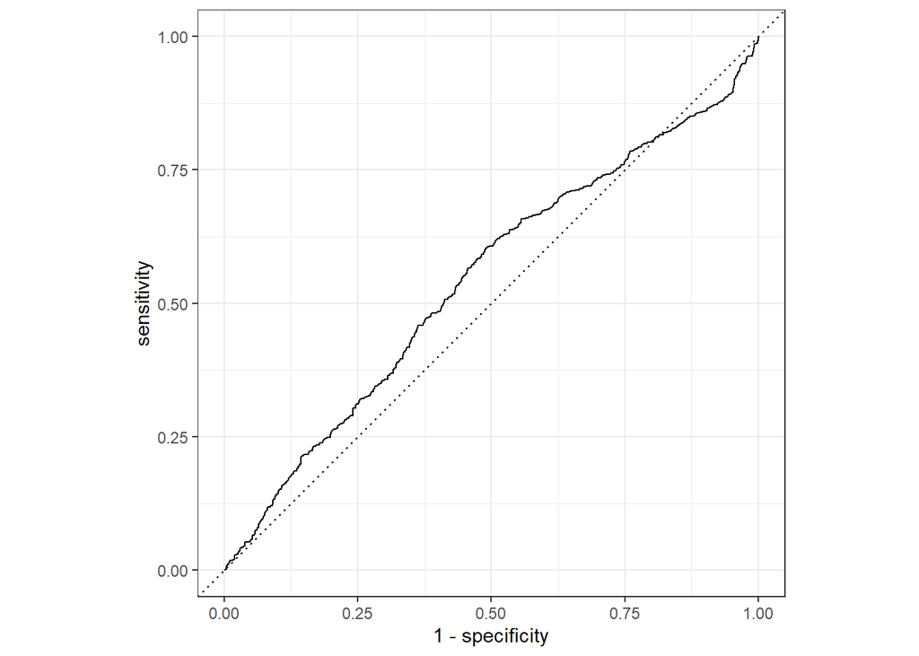

```r
#rock the curve!
goodDanishData %>%
  roc_curve(truth = Diagnosis, PredictionsPerc) %>%
  autoplot()
```

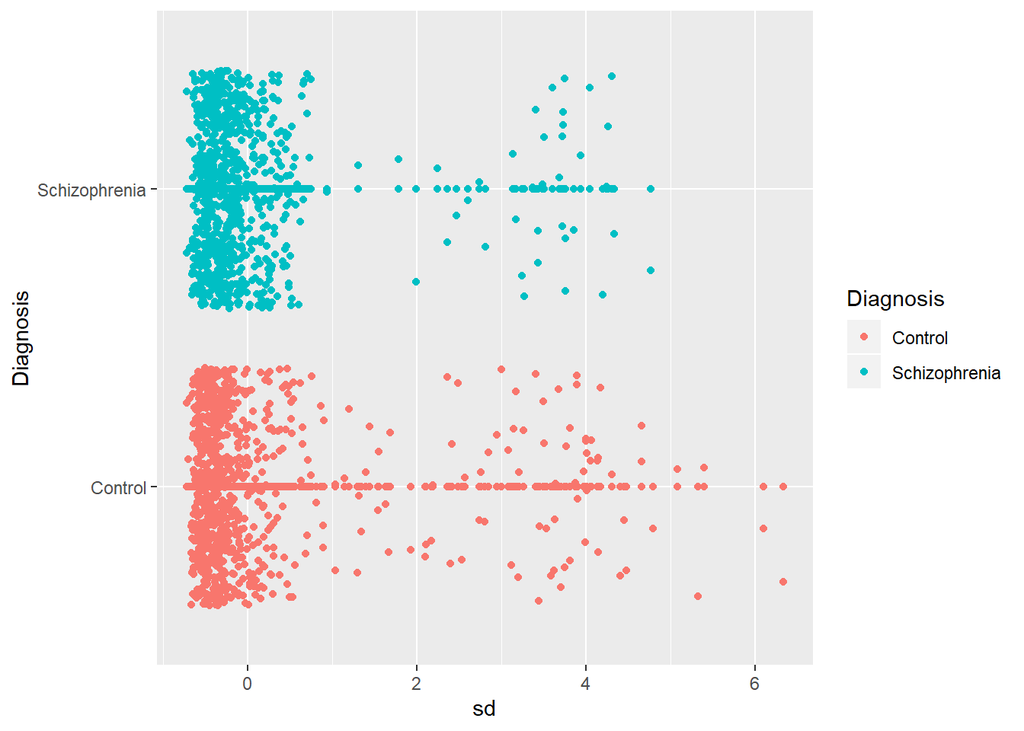

```r
#making scatterplot
ggplot(goodDanishData,aes(x=sd,y=Diagnosis,color=Diagnosis))+geom_point()+geom_jitter()
```

```r
# set seed used in partitioning
set.seed(5)
# partition the data so that diagnosis is equally balanced between folds
tidyDataList <- partition(tidyData, p = 0.2, cat_col = c("Diagnosis"), id_col = NULL, list_out = T)

# create partitioned test and train dataframes from the list of dataframes
tidyDataTest <- tidyDataList[[1]]
tidyDataTrain <- tidyDataList[[2]]

#tidyDataTest$uID <- as.factor(paste(as.character(tidyDataTest$uID),"_test"))

# create a recipe that trains the data to a model created from all variable predictors in the tidyDataTrain data frame
rec <- tidyDataTrain %>% recipe(Diagnosis ~ .) %>% # define the outcome
  step_center(all_numeric()) %>% # center numeric predictors
  step_scale(all_numeric()) %>% # scale numeric predictors
  step_corr(all_numeric()) %>%
  prep(training = tidyDataTrain)

# extract finalized training set from recipe
trainBaked <- juice(rec)

# inspect recipe
rec
```

```
## Data Recipe
##
## Inputs:
##
##       role #variables
##    outcome          1
##  predictor         15
##
## Training data contained 1332 data points and no missing data.
##
## Operations:
##
## Centering for Age, nsyll, dur..s., ... [trained]
## Scaling for Age, nsyll, dur..s., ... [trained]
## Correlation filter removed dur..s., nsyll, sd [trained]
```

```r
# apply the trained data recipe to test dataframe
testBaked <- rec %>% bake(tidyDataTest)

# fit logistic regression model with all predictors included to the training data set
logFit <-
  logistic_reg() %>%
  set_mode("classification") %>%
  set_engine("glm") %>%
  fit(Diagnosis ~ . , data = trainBaked)

# fit support vector machine model with all predictors included to the training data set
svmFit <-
  svm_rbf() %>%
  set_mode("classification") %>%
  set_engine("kernlab") %>%
  fit(Diagnosis ~ . , data = trainBaked)

# predict class (Diagnosis/Control) using the fitted logistic model
logClass <- logFit %>%
  predict(new_data = testBaked)
# predict probabilities of classes (Diagnosis/Control)
logProb <- logFit %>%
  predict(new_data = testBaked, type = "prob") %>%
  pull(.pred_Schizophrenia)
# get multiple predictions at once, creating a dataframe with assigned probabilities and classes for the two types of model types (logistic and svm)
testResults <-
  testBaked %>%
  select(Diagnosis) %>%
  mutate(
    logClass = predict(logFit, new_data = testBaked) %>%
      pull(.pred_class),
    logProb  = predict(logFit, new_data = testBaked, type = "prob") %>%
      pull(.pred_Schizophrenia),
    svmClass = predict(svmFit, new_data = testBaked) %>%
      pull(.pred_class),
    svmProb  = predict(svmFit, new_data = testBaked, type = "prob") %>%
      pull(.pred_Schizophrenia)
  )
# examine the first 5 elements in the dataframe
testResults %>%
  head(5) %>%
  knitr::kable()
```

| Diagnosis | logClass | logProb | svmClass | svmProb |
| --- | --- | --- | --- | --- |
| Control | Control | 0.4038203 | Control | 0.2309937 |
| Control | Schizophrenia | 0.5610025 | Control | 0.2955010 |
| Control | Schizophrenia | 0.5291445 | Control | 0.3832337 |
| Control | Schizophrenia | 0.5607973 | Schizophrenia | 0.6245331 |
| Control | Control | 0.4888427 | Control | 0.4628473 |

```r
# calculate performance metrics from the logistic regression predictions
metrics(testResults, truth = Diagnosis, estimate = logClass) %>%
  knitr::kable()
```

| .metric | .estimator | .estimate |
| --- | --- | --- |
| accuracy | binary | 0.5572289 |
| kap | binary | 0.1104549 |

```r
# calculate performance metrics from the support vector machine predictions
metrics(testResults, truth = Diagnosis, estimate = svmClass) %>%
  knitr::kable()
```

| .metric | .estimator | .estimate |
| --- | --- | --- |
| accuracy | binary | 0.6385542 |
| kap | binary | 0.2735230 |

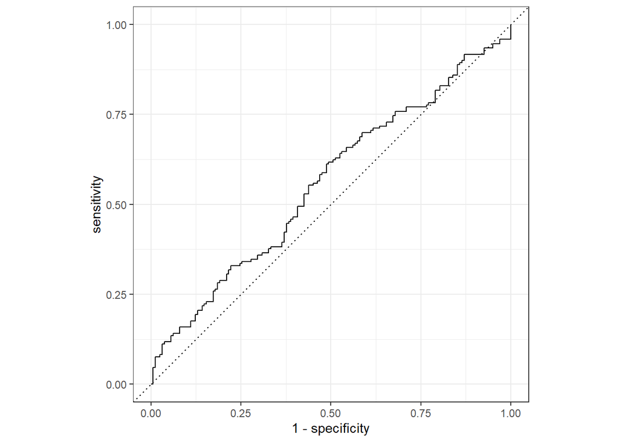

```r
# plot the ROC (receiver operating characteristic) curve
testResults %>%
  roc_curve(truth = Diagnosis, logProb) %>%
  autoplot()
```

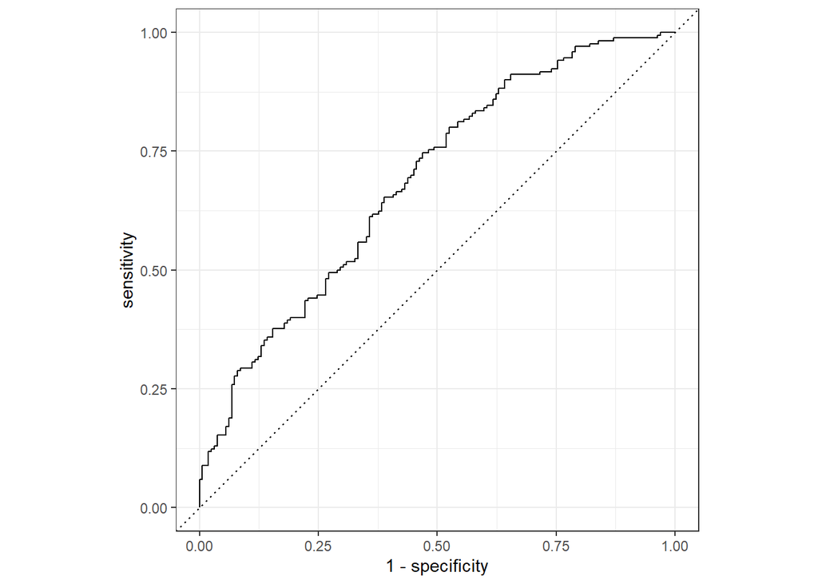

```r
# plot the ROC (receiver operating characteristic) curve
testResults %>%
  roc_curve(truth = Diagnosis, svmProb) %>%
  autoplot()
```

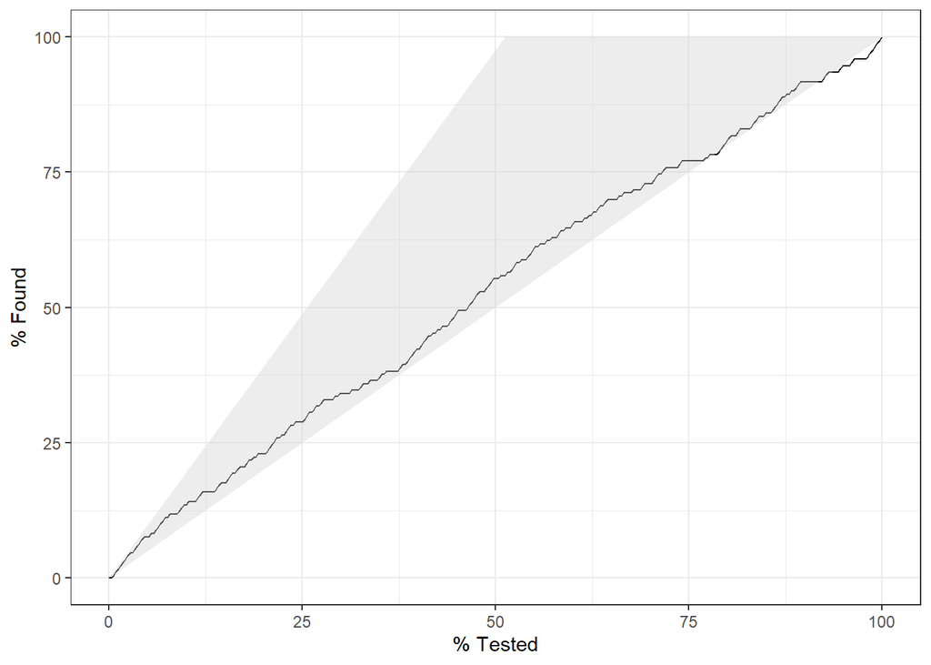

```r
# plot the gain curve
testResults %>%
  mutate(logProb = 1 - logProb) %>% # for the plot to show correctly (otherwise the line would be flipped)
  gain_curve(truth = Diagnosis, logProb) %>%
  autoplot()
```

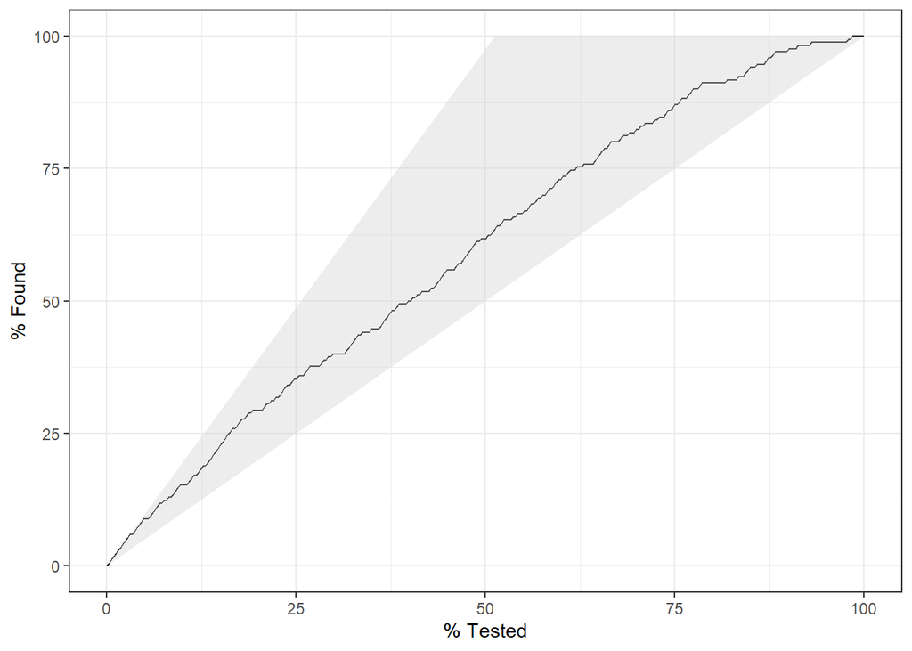

```r
# plot the gain curve
testResults %>%
  mutate(svmProb = 1 - svmProb) %>% # for the plot to show correctly (otherwise the line would be flipped)
  gain_curve(truth = Diagnosis, svmProb) %>%
  autoplot()
```

```r
# create 10 folds over 10 iterations, diagnosis is balanced across folds
cvFolds <- vfold_cv(tidyDataTrain, v = 10, repeats = 10, strata = Diagnosis)

# prepare data set and fetch training data
cvFolds <- cvFolds %>%
  mutate(recipes = splits %>%
           map(prepper, recipe = rec),
         train_data = splits %>% map(training))


# create a model, which is not fitted to our training data
logFit <-
  logistic_reg() %>%
  set_mode("classification") %>%
  set_engine("glm")

svmFit <-
  svm_rbf() %>%
  set_mode("classification") %>%
  set_engine("kernlab")

# train the model on each fold
cvFoldsLog <- cvFolds %>%  mutate(
  logFits = pmap(list(recipes, train_data), #input
                            ~ fit(logFit, formula(.x), data = bake(object = .x, new_data = .y)) # function to apply
                 ))

# train the model on each fold
cvFoldsSVM <- cvFolds %>%  mutate(
  svmFits = pmap(list(recipes, train_data), #input
                            ~ fit(svmFit, formula(.x), data = bake(object = .x, new_data = .y)) # function to apply
                 ))



# create a function that takes split data, recipe and model and returns a tibble of the actual and predicted data
predictLog <- function(split, rec, model) {
  bakedTestLog <- bake(rec, testing(split))
  tibble(
    actual = bakedTestLog$Diagnosis,
    predicted = predict(model, new_data = bakedTestLog) %>% pull(.pred_class),
    prop_Schizophrenia =  predict(model, new_data = bakedTestLog, type = "prob") %>% pull(.pred_Schizophrenia),
    prop_Control =  predict(model, new_data = bakedTestLog, type = "prob") %>% pull(`.pred_Control`)
  )
}

predictSVM <- function(split, rec, model) {
  bakedTestSVM <- bake(rec, testing(split))
  tibble(
    actual = bakedTestSVM$Diagnosis,
    predicted = predict(model, new_data = bakedTestSVM) %>% pull(.pred_class),
    prop_Schizophrenia =  predict(model, new_data = bakedTestSVM, type = "prob") %>% pull(.pred_Schizophrenia),
    prop_Control =  predict(model, new_data = bakedTestSVM, type = "prob") %>% pull(`.pred_Control`)
  )
}


# apply our function predictLog to each split, with their respective recipes and models and save the actual and predicted data to a new column
cvFoldsLog <- cvFoldsLog %>%
  mutate(pred = pmap(list(splits, recipes, logFits) , predictLog))
```

[output not shown]

[output cut: 844 more lines]

[output not shown]

```r
cvFoldsSVM <- cvFoldsSVM %>%
  mutate(pred = pmap(list(splits, recipes, svmFits) , predictSVM))

##################################### EVALUATING MODELS ############################################

# create a dataframe containing the information about folds and iterations as well as metrics on accuracy, kappa value, roc area under curve, and mean logarithmic loss
evalLog <-
  cvFoldsLog %>%
  mutate(
    metrics = pmap(list(pred), ~ metrics(., truth = actual, estimate = predicted, prop_Schizophrenia))) %>%
  select(id, id2, metrics) %>%
  unnest(metrics)

evalSVM <-
  cvFoldsSVM %>%
  mutate(
    metrics = pmap(list(pred), ~ metrics(., truth = actual, estimate = predicted, prop_Schizophrenia))) %>%
  select(id, id2, metrics) %>%
  unnest(metrics)

# create dataframe with performance metrics and inspect the first 15 rows in the dataframe
evalLog %>%
  select(repeat_n = id, fold_n = id2, metric = .metric, estimate = .estimate) %>%
  spread(metric, estimate) %>%
  head(15) %>%
  knitr::kable()
```

| repeat_n | fold_n | accuracy | kap | mn_log_loss | roc_auc |
| --- | --- | --- | --- | --- | --- |
| Repeat01 | Fold01 | 0.5746269 | 0.1442976 | 0.7177265 | 0.5732441 |
| Repeat01 | Fold02 | 0.6268657 | 0.2497200 | 0.7407290 | 0.6557414 |
| Repeat01 | Fold03 | 0.5298507 | 0.0592824 | 0.7196287 | 0.5413601 |
| Repeat01 | Fold04 | 0.5597015 | 0.1166480 | 0.7313785 | 0.5761427 |
| Repeat01 | Fold05 | 0.5187970 | 0.0357952 | 0.7297431 | 0.5644796 |
| Repeat01 | Fold06 | 0.5263158 | 0.0472996 | 0.7374179 | 0.5875566 |
| Repeat01 | Fold07 | 0.5413534 | 0.0806799 | 0.7227819 | 0.5287330 |
| Repeat01 | Fold08 | 0.5112782 | 0.0203966 | 0.7245133 | 0.5538462 |
| Repeat01 | Fold09 | 0.5606061 | 0.1171587 | 0.7326028 | 0.5875460 |
| Repeat01 | Fold10 | 0.5530303 | 0.1048276 | 0.7295309 | 0.5737592 |
| Repeat02 | Fold01 | 0.5149254 | 0.0250728 | 0.7073341 | 0.5025641 |
| Repeat02 | Fold02 | 0.5671642 | 0.1312318 | 0.7366552 | 0.6153846 |
| Repeat02 | Fold03 | 0.5820896 | 0.1626869 | 0.7460287 | 0.6465998 |
| Repeat02 | Fold04 | 0.5522388 | 0.1012743 | 0.7246286 | 0.5768116 |
| Repeat02 | Fold05 | 0.5639098 | 0.1273756 | 0.7368080 | 0.6133484 |

```r
# create dataframe with performance metrics and inspect the first 15 rows in the dataframe
evalSVM %>%
  select(repeat_n = id, fold_n = id2, metric = .metric, estimate = .estimate) %>%
  spread(metric, estimate) %>%
  head(15) %>%
  knitr::kable()
```

| repeat_n | fold_n | accuracy | kap | mn_log_loss | roc_auc |
| --- | --- | --- | --- | --- | --- |
| Repeat01 | Fold01 | 0.6567164 | 0.3109770 | 0.8755754 | 0.7362319 |
| Repeat01 | Fold02 | 0.7910448 | 0.5809694 | 0.9922052 | 0.8452620 |
| Repeat01 | Fold03 | 0.5970149 | 0.1911469 | 0.8861177 | 0.6992196 |
| Repeat01 | Fold04 | 0.6492537 | 0.2975686 | 0.8911456 | 0.6885173 |
| Repeat01 | Fold05 | 0.6616541 | 0.3204269 | 0.9190364 | 0.7384615 |
| Repeat01 | Fold06 | 0.6466165 | 0.2916714 | 0.9255331 | 0.7174208 |
| Repeat01 | Fold07 | 0.5714286 | 0.1415468 | 0.8586600 | 0.6090498 |
| Repeat01 | Fold08 | 0.6616541 | 0.3227340 | 0.8571495 | 0.6911765 |
| Repeat01 | Fold09 | 0.5833333 | 0.1632089 | 0.8442564 | 0.6295956 |
| Repeat01 | Fold10 | 0.6439394 | 0.2836028 | 0.8856825 | 0.7196691 |
| Repeat02 | Fold01 | 0.6417910 | 0.2784384 | 0.8689581 | 0.7079153 |
| Repeat02 | Fold02 | 0.7164179 | 0.4313156 | 0.9628871 | 0.7810479 |
| Repeat02 | Fold03 | 0.7164179 | 0.4297872 | 0.9190283 | 0.7487179 |
| Repeat02 | Fold04 | 0.5970149 | 0.1918696 | 0.8454151 | 0.6405797 |
| Repeat02 | Fold05 | 0.5714286 | 0.1415468 | 0.9002879 | 0.6902715 |